# Project

Benjamin Huang, Sueking Leung

2024-03-31

#Part 1 Convolutions ##In this part, you will see the effect of adding two distributions together. Simulate 𝑋1, 𝑋2, and then compute their sum 𝑌 = 𝑋1 + 𝑋2. Classify Y as an (a, b, 0) distribution and give its parameters.

```r
sample_size <- 10000
beta1 <- 12
beta2 <- 12

set.seed(461)
x1 <- rgeom(sample_size, 1/(1+beta1)) # Geometric distribution with beta = 12
x2 <- rgeom(sample_size, 1/(1+beta2))
y <- x1 + x2
(table <- table(y))
```

```
## y
##   0   1   2   3   4   5   6   7   8   9  10  11  12  13  14  15  16  17  18  19
##  65 128 146 191 198 224 282 248 277 282 288 294 277 320 304 282 273 280 252 240
##  20  21  22  23  24  25  26  27  28  29  30  31  32  33  34  35  36  37  38  39
## 240 236 238 242 221 223 201 187 174 164 186 175 164 155 124 137 116 113 121 111
##  40  41  42  43  44  45  46  47  48  49  50  51  52  53  54  55  56  57  58  59
##  93  85  96  72  67  65  62  57  59  55  56  48  58  44  32  34  39  34  34  31
##  60  61  62  63  64  65  66  67  68  69  70  71  72  73  74  75  76  77  78  79
##  28  39  22  19  20  17  21  27  15  20  20  21  13  19  18  10  14  16  15   6
##  80  81  82  83  84  85  86  87  88  89  90  91  92  93  94  95  97  98  99 100
##   9   6   6   5   8   3   5   6   6   6   4  10   5   2   2   4   2   2   1   3
## 101 102 105 106 108 109 110 115 119 121 123 124 127 129 132 146
##   2   1   2   1   3   2   3   1   1   1   2   1   1   1   2   1
```

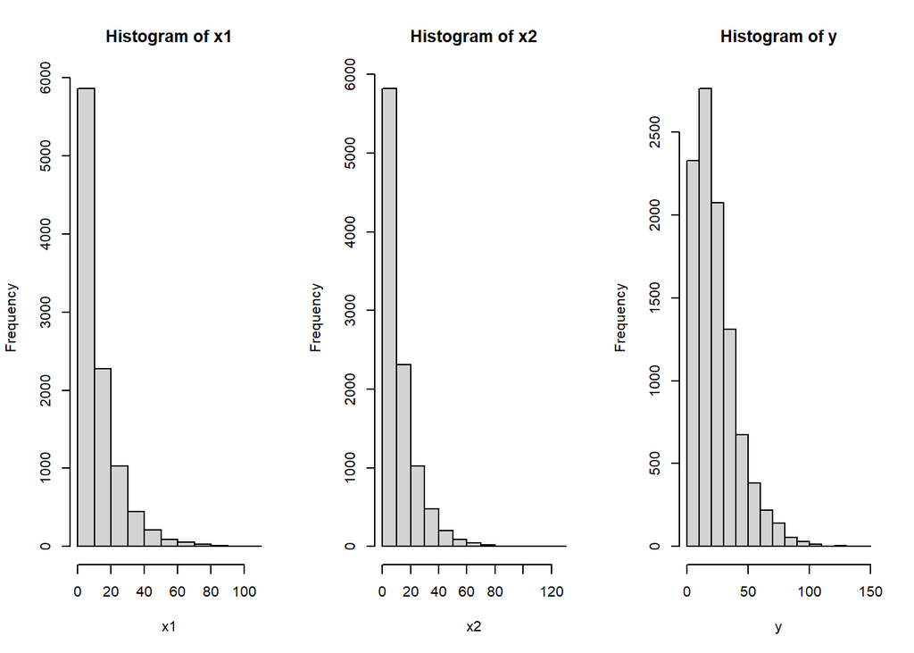

```r
par(mfrow = c(1,3))
hist(x1)
hist(x2)
hist(y)
```

```r
p <- numeric(60)
for (i in 1:60) {
  p[i] <- (i+1)*table[i+1]/table[i]
}
p
```

```
##  [1]  3.938462  3.421875  5.232877  5.183246  6.787879  8.812500  7.035461
##  [8] 10.052419 10.180505 11.234043 12.250000 12.248299 16.173285 14.250000
## [15] 14.842105 16.457447 18.461538 17.100000 19.047619 21.000000 21.633333
## [22] 23.194915 24.403361 22.830579 26.235294 24.336323 26.049751 26.983957
## [29] 28.275862 35.158537 30.107527 30.925714 32.134146 28.000000 39.774194
## [36] 31.328467 37.017241 41.761062 36.694215 34.351351 38.387097 48.564706
## [43] 33.000000 41.875000 44.626866 44.830769 44.129032 50.719298 46.610169
## [50] 51.927273 44.571429 64.041667 40.965517 40.000000 59.500000 65.382353
## [57] 50.564103 59.000000 54.705882 55.096774
```

```r
x <- 2:61
lm(p[1:60]~x) # pick samples that are large enough
```

```
##
## Call:
## lm(formula = p[1:60] ~ x)
##
## Coefficients:
## (Intercept)            x
##      1.0020       0.9277
```

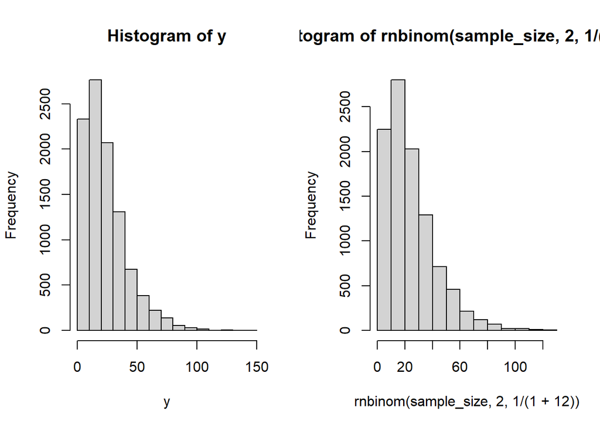

```r
# We get a = .93, b = 1, since a > 0, we determine y follows a Negative Binomial distribution.
# Through NB distribution's formulas, we get r = 2, beta = 12.

par(mfrow = c(1, 2))
hist(y, breaks = 15)
hist(rnbinom(sample_size, 2, 1/(1+12)), breaks = 15)
```

```r
sample_size <- 10000
trial1 <- 24
trial2 <- 36
success1 <- 0.6
success2 <- 0.6
set.seed(461)

x1 <- rbinom(sample_size, trial1, success1) # Binomial distribution with m = 24, q = 0.6
x2 <- rbinom(sample_size, trial2, success2) # Binomial distribution with m = 36, q = 0.6
y <- x1 + x2
(table <- table(y))
```

```
## y
##   22   23   24   25   26   27   28   29   30   31   32   33   34   35   36   37
##    1    8    8   19   47   58  120  206  301  426  593  743  840 1020 1043 1008
##   38   39   40   41   42   43   44   45   46   47   48   49   51
##  979  780  666  454  276  196  100   48   38   16    3    2    1
```

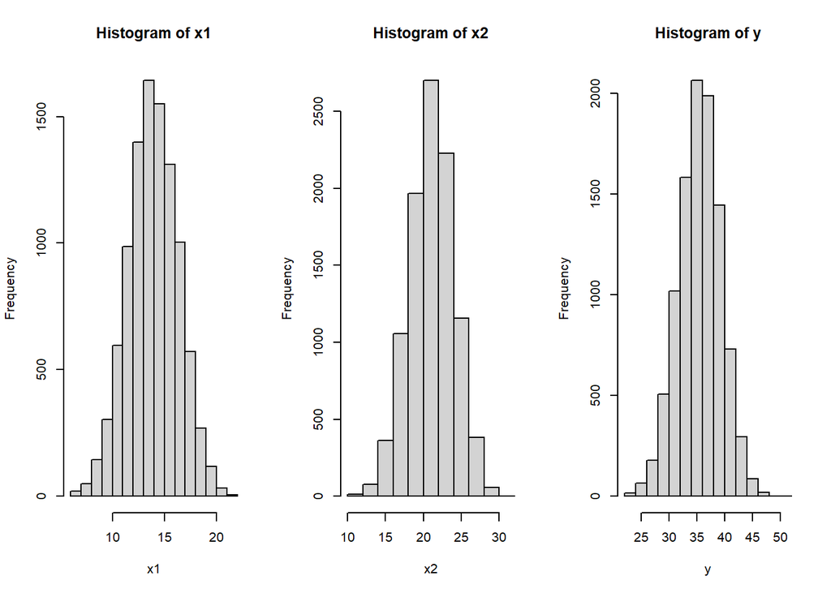

```r
par(mfrow = c(1,3))
hist(x1)
hist(x2)
hist(y)
```

```r
p <- numeric(24)
for (i in 1:24) {
  p[i] <- (i+22)*table[i+1]/table[i]
}
p
```

```
##  [1] 184.00000  24.00000  59.37500  64.31579  33.31915  57.93103  49.78333
##  [8]  43.83495  43.87375  44.54460  41.34739  38.43876  42.50000  36.81176
## [15]  35.75839  36.90675  31.07252  34.15385  27.94895  25.53304  30.53623
## [22]  22.44898  21.60000  36.41667
```

```r
x <- 26:46
lm(p[4:24]~x) # pick samples that are large enough
```

```
##
## Call:
## lm(formula = p[4:24] ~ x)
##
## Coefficients:
## (Intercept)            x
##      88.296       -1.396
```

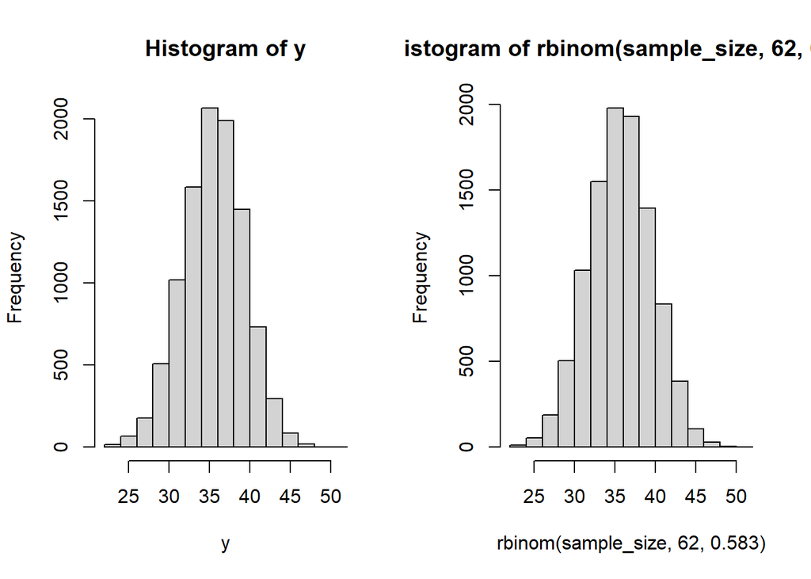

```r
# We get a = -1.4, b = 88.3, since a < 0, we determine y follows a Binomial distribution.
# Through Binomial distribution's formulas, we get m = 62, q = 0.583.

par(mfrow = c(1, 2))
hist(y, breaks = 15)
hist(rbinom(sample_size, 62, 0.583), breaks = 15)
```

```r
sample_size <- 10000
lambda1 <- 16
lambda2 <- 20
set.seed(461)

x1 <- rpois(sample_size, lambda1) # Poisson distribution with lambda = 16
x2 <- rpois(sample_size, lambda2) # Poisson distribution with lambda = 20
y <- x1 + x2
(table <- table(y))
```

```
## y
##  14  17  18  19  20  21  22  23  24  25  26  27  28  29  30  31  32  33  34  35
##   2   1   6   7  12  23  40  56  82 120 176 232 279 360 448 503 572 627 669 663
##  36  37  38  39  40  41  42  43  44  45  46  47  48  49  50  51  52  53  54  55
## 672 623 554 551 512 462 365 338 246 206 163 122  82  63  54  29  29  16  14  10
##  56  57  58  59  60  62
##   5   2   1   1   1   1
```

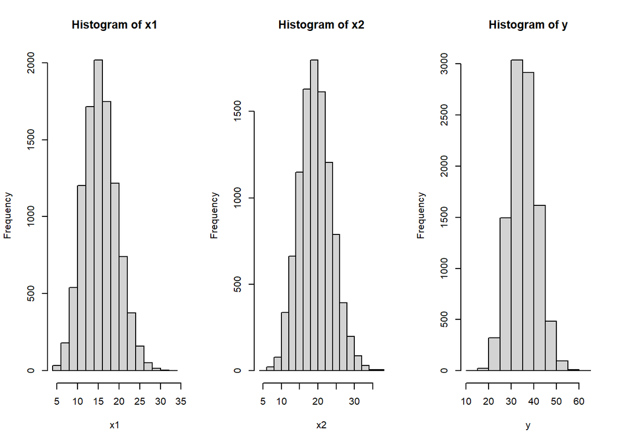

```r
par(mfrow = c(1,3))
hist(x1)
hist(x2)
hist(y)
```

```r
p <- numeric(40)
for (i in 1:40) {
  p[i] <- (i+17)*table[i+2]/table[i+1]
}
p
```

```
##  [1] 108.00000  22.16667  34.28571  40.25000  38.26087  32.20000  35.14286
##  [8]  36.58537  38.13333  35.59091  33.67241  37.41935  37.33333  34.80580
## [15]  36.38966  36.17308  36.27751  34.68610  36.48869  34.30208  33.79133
## [22]  38.78881  37.16878  36.99609  33.18182  39.81918  32.02367  37.68293
## [29]  36.39806  35.17791  32.26230  37.64634  42.85714  27.38889  52.00000
## [36]  29.24138  47.25000  39.28571  28.00000  22.80000
```

```r
x <- 21:52
lm(p[4:35]~x) # pick samples that are large enough
```

```
##
## Call:
## lm(formula = p[4:35] ~ x)
##
## Coefficients:
## (Intercept)            x
##    34.62612      0.05039
```

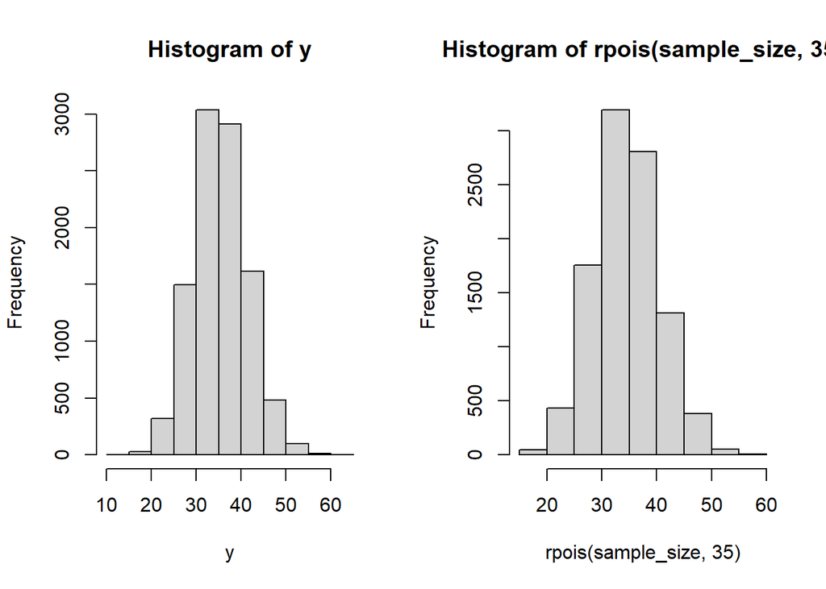

```r
# We get a = 0.05, b = 34.6, since a is very close to 0, we determine y follows a Poisson distribution.
# Through Poisson distribution's formulas, we get lambda = 35

par(mfrow = c(1, 2))
hist(y, breaks = 15)
hist(rpois(sample_size, 35), breaks = 10)
```

#Part 2 Compound Distributions ##In this part, you will create a collective risk model with N being the number of claims and 𝑋𝑖 being the amount of loss. Simulate 𝑁, 𝑋𝑖, and the sum 𝑆 = 𝑋1 + 𝑋2 + ⋯ + 𝑋𝑁. Compute 𝐸[𝑆], 𝑉𝑎𝑟[𝑆], and compare to the theoretical values using the law of total expectation.

```r
sample_size <- 10000
lambda <- 25
theta <- 100
set.seed(441)

n1 <- rpois(sample_size, lambda) # create the distribution for number of claims first
s1 <- numeric(sample_size) # create a vector for the sum
for (i in 1:sample_size) {
  x_i <- rexp(n1[i], 1/theta) # create x_i for the ith number of claims
  s1[i] <- sum(x_i)
}

mean_s1 <- mean(s1)
var_s1 <- var(s1)
cat("mean of aggregate loss by S1:", mean_s1, "\n")
```

```
## mean of aggregate loss by S1: 2489.794
```

```r
cat("variance of aggregate loss by S1:", var_s1, "\n")
```

```
## variance of aggregate loss by S1: 492648.3
```

```r
sample_size <- 10000
lambda <- 25
theta <- 100
set.seed(441)

s2 <- numeric(sample_size) # create a vector for the sum
for(k in 1:sample_size){
  n2 <- rpois(1, lambda) # create the distribution for number of claims inside the loop
  x2 <- rexp(n2, 1/theta) # create  n2 x2
  s2[k] <- sum(x2)
}

mean_s2 <- mean(s2)
var_s2 <- var(s2)
cat("mean of aggregate loss by S2:", mean_s2, "\n")
```

```
## mean of aggregate loss by S2: 2495.228
```

```r
cat("variance of aggregate loss by S2:", var_s2)
```

```
## variance of aggregate loss by S2: 495309.7
```

$$
$$\begin{align*}
& N \sim Poi(\lambda = 25), \: X \sim Exp(\theta = 100)
\\
& E(N) = \lambda = 25, \: Var(N) = \lambda = 25
\\
& E(X) = \theta^{1} \times 1! = 100, \: E(X^{2}) = \theta^{2} \times
2! = 20000, \: Var(X) = 10000
\\
& \therefore E(S) = E(N) \times E(X) = 2500, \: Var(S) = E(N) \times
Var(X) + Var(N) \times E(X)^{2} = 500000
\end{align*}$$
$$

```r
sample_size <- 10000
lambda <- 100
mu <- 1
sigma <- 2
set.seed(441)

n1 <- rpois(sample_size, lambda) # create the distribution for number of claims first
s1 <- numeric(sample_size) # create a vector for the sum
for (i in 1:sample_size) {
  x_i <- rlnorm(n1[i], meanlog = mu, sdlog = sigma) # create x_i for the ith number of claims
  s1[i] <- sum(x_i)
}


mean_s1 <- mean(s1)
var_s1 <- var(s1)
cat("mean of aggregate loss by S1:", mean_s1, "\n")
```

```
## mean of aggregate loss by S1: 2025.958
```

```r
cat("variance of aggregate loss by S1:", var_s1, "\n")
```

```
## variance of aggregate loss by S1: 1887151
```

```r
sample_size <- 10000
lambda <- 100
mu <- 1
sigma <- 2
set.seed(441)

s2 <- numeric(sample_size) # create a vector for the sum
for (k in 1:sample_size) {
  n2 <- rpois(1, lambda) # create the distribution for number of claims inside the loop
  x2 <- rlnorm(n2, mu, sigma) # create  n2 x2
  s2[k] <- sum(x2)
}

mean_s2 <- mean(s2)
var_s2 <- var(s2)
cat("mean of aggregate loss by S2:", mean_s2, "\n")
```

```
## mean of aggregate loss by S2: 1997.262
```

```r
cat("variance of aggregate loss by S2:", var_s2)
```

```
## variance of aggregate loss by S2: 1716529
```

$$
$$\begin{align*}
& N \sim Poi(\lambda = 100), \: X \sim Lognormal(\mu = 1, \sigma =
2)
\\
& E(N) = \lambda = 100, \: Var(N) = \lambda = 100
\\
& E(X) = exp(\mu + \frac{1}{2}\sigma^{2}) \approx 20.09, \: E(X^{2})
= exp(2\mu + 2\sigma^{2}) \approx 22026.47, \: Var(X) \approx 21622.86
\\
& \therefore E(S) = E(N) \times E(X) = 2009, \: Var(S) = E(N) \times
Var(X) + Var(N) \times E(X)^{2} = 2202646.81
\end{align*}$$
$$

```r
sample_size <- 10000
trial <- 36
success <- 0.6
alpha <- 100
beta <- 2
set.seed(441)

n1 <- rbinom(sample_size, trial, success) # create the distribution for number of claims first
s1 <- numeric(sample_size) # create a vector for the sum
for (i in 1:sample_size) {
  x_i <- rgamma(n1[i], shape = alpha, rate = 1/beta) # create x_i for the ith number of claims
  s1[i] <- sum(x_i)
}

mean_s1 <- mean(s1)
var_s1 <- var(s1)
cat("mean of aggregate loss by S1:", mean_s1, "\n")
```

```
## mean of aggregate loss by S1: 4326.69
```

```r
cat("variance of aggregate loss by S1:", var_s1, "\n")
```

```
## variance of aggregate loss by S1: 357415.6
```

```r
sample_size <- 10000
trial <- 36
success <- 0.6
alpha <- 100
beta <- 2
set.seed(441)

s2 <- numeric(sample_size) # create a vector for the sum
for (k in 1:sample_size) {
  n2 <- rbinom(1, trial, success) # create the distribution for number of claims inside the loop
  x2 <- rgamma(n2, shape = alpha, rate = 1/beta) # create  n2 x2
  s2[k] <- sum(x2)
}

mean_s2 <- mean(s2)
var_s2 <- var(s2)
cat("mean of aggregate loss by S2:", mean_s2, "\n")
```

```
## mean of aggregate loss by S2: 4322.938
```

```r
cat("variance of aggregate loss by S2:", var_s2)
```

```
## variance of aggregate loss by S2: 358285.6
```

$$
$$\begin{align*}
& N \sim Bin(m = 36, q = 0.6), \: X \sim Gamma(\alpha = 100, \theta
= 2)
\\
& E(N) = mq = 21.6, \: Var(N) = mq(1-q) = 8.64
\\
& E(X) = \theta^{1}(\alpha + 1 - 1) = 200, \: E(X^{2}) =
\theta^{2}(\alpha + 2 - 1)(\alpha + 1 -1) = 40400, \: Var(X) = 400
\\
& \therefore E(S) = E(N) \times E(X) = 4320, \: Var(S) = E(N) \times
Var(X) + Var(N) \times E(X)^{2} = 354240
\end{align*}$$
$$

#Part 3 Credibility Theory #For each of the three models in Part 2, determine the credibility standards with $$
$$\begin{align*}
& For \: r = 0.01, p = 0.9,
\\
& N = Poi(\lambda = 25), \: X_{i} = Exp(\theta = 100 ): \: E(S) =
2500, \: Var(S) = 500000
\\
& N = Poi(\lambda = 100), \: X_{i} = LogNormal(\mu = 1, \sigma = 2
): \: E(S) = 2009, \: Var(S) = 2202646.81
\\
& N = Bin(m = 36, q = 0.6), \: X_{i} = Gamma(\alpha = 100, \theta =
2 ): \: E(S) = 4320, \: Var(S) = 354240
\\
& \mathbb{P}\{ -r\xi \leq \bar{X} - \xi \leq r\xi \} \geq p, \:
\mathbb{P}(|\frac{\bar{X}-\xi}{\sigma/\sqrt{n}}| \leq
\frac{r\xi\sqrt{n}}{\sigma}) \geq p
\\
& \Rightarrow \mathbb{P}(|\frac{\bar{X}-E(X)}{\sqrt{Var(\bar{X})}}|
\leq \frac{rE(X)}{\sqrt{Var(\bar{X})}}=y_{p}) \geq p
\\
& Let \: X = S(Aggregate \: Loss)
\\
& For \: N = Poi(\lambda = 25), \: X_{i} = Exp(\theta = 100 ):
\\
& \frac{rE(X)}{\sqrt{Var(\bar{X})}} = \frac{0.01 \times
2500}{\sqrt{500000/10000}} \approx 3.536 \geq y_{0.95} = 1.645
\\
\\
& For \: N = Poi(\lambda = 100), \: X_{i} = LogNormal(\mu = 1,
\sigma = 2 ):
\\
& \frac{rE(X)}{\sqrt{Var(\bar{X})}} = \frac{0.01 \times
2009}{\sqrt{2202646.81/10000}} \approx 1.354 \leq y_{0.95} = 1.645
\\
\\
& For \: N = Bin(m = 36, q = 0.6), \: X_{i} = Gamma(\alpha = 100,
\theta = 2 ):
\\
& \frac{rE(X)}{\sqrt{Var(\bar{X})}} = \frac{0.01 \times
4320}{\sqrt{354240/10000}} \approx 7.258 \geq y_{0.95} = 1.645
\end{align*}$$
$$

$$
$$\begin{align*}
& For \: r = 0.05, p = 0.95,
\\
& N = Poi(\lambda = 25), \: X_{i} = Exp(\theta = 100 ): \: E(S) =
2500, \: Var(S) = 500000
\\
& N = Poi(\lambda = 100), \: X_{i} = LogNormal(\mu = 1, \sigma = 2
): \: E(S) = 2009, \: Var(S) = 2202646.81
\\
& N = Bin(m = 36, q = 0.6), \: X_{i} = Gamma(\alpha = 100, \theta =
2 ): \: E(S) = 4320, \: Var(S) = 354240
\\
& \mathbb{P}\{ -r\xi \leq \bar{X} - \xi \leq r\xi \} \geq p, \:
\mathbb{P}(|\frac{\bar{X}-\xi}{\sigma/\sqrt{n}}| \leq
\frac{r\xi\sqrt{n}}{\sigma}) \geq p
\\
& \Rightarrow \mathbb{P}(|\frac{\bar{X}-E(X)}{\sqrt{Var(\bar{X})}}|
\leq \frac{rE(X)}{\sqrt{Var(\bar{X})}}=y_{p}) \geq p
\\
& Let \: X = S(Aggregate \: Loss)
\\
& For \: N = Poi(\lambda = 25), \: X_{i} = Exp(\theta = 100 ):
\\
& \frac{rE(X)}{\sqrt{Var(\bar{X})}} = \frac{0.05 \times
2500}{\sqrt{500000/10000}} \approx 17.678 \geq y_{0.975} = 1.96
\\
\\
& For \: N = Poi(\lambda = 100), \: X_{i} = LogNormal(\mu = 1,
\sigma = 2 ):
\\
& \frac{rE(X)}{\sqrt{Var(\bar{X})}} = \frac{0.05 \times
2009}{\sqrt{2202646.81/10000}} \approx 6.768 \geq y_{0.975} = 1.96
\\
\\
& For \: N = Bin(m = 36, q = 0.6), \: X_{i} = Gamma(\alpha = 100,
\theta = 2 ):
\\
& \frac{rE(X)}{\sqrt{Var(\bar{X})}} = \frac{0.05 \times
4320}{\sqrt{354240/10000}} \approx 36.292 \geq y_{0.975} = 1.96
\end{align*}$$
$$

$$
$$\begin{align*}
& For \: r = 0.10, p = 0.99,
\\
& N = Poi(\lambda = 25), \: X_{i} = Exp(\theta = 100 ): \: E(S) =
2500, \: Var(S) = 500000
\\
& N = Poi(\lambda = 100), \: X_{i} = LogNormal(\mu = 1, \sigma = 2
): \: E(S) = 2009, \: Var(S) = 2202646.81
\\
& N = Bin(m = 36, q = 0.6), \: X_{i} = Gamma(\alpha = 100, \theta =
2 ): \: E(S) = 4320, \: Var(S) = 354240
\\
& \mathbb{P}\{ -r\xi \leq \bar{X} - \xi \leq r\xi \} \geq p, \:
\mathbb{P}(|\frac{\bar{X}-\xi}{\sigma/\sqrt{n}}| \leq
\frac{r\xi\sqrt{n}}{\sigma}) \geq p
\\
& \Rightarrow \mathbb{P}(|\frac{\bar{X}-E(X)}{\sqrt{Var(\bar{X})}}|
\leq \frac{rE(X)}{\sqrt{Var(\bar{X})}}=y_{p}) \geq p
\\
& Let \: X = S(Aggregate \: Loss)
\\
& For \: N = Poi(\lambda = 25), \: X_{i} = Exp(\theta = 100 ):
\\
& \frac{rE(X)}{\sqrt{Var(\bar{X})}} = \frac{0.1 \times
2500}{\sqrt{500000/10000}} \approx 35.355 \geq y_{0.995} = 2.575
\\
\\
& For \: N = Poi(\lambda = 100), \: X_{i} = LogNormal(\mu = 1,
\sigma = 2 ):
\\
& \frac{rE(X)}{\sqrt{Var(\bar{X})}} = \frac{0.1 \times
2009}{\sqrt{2202646.81/10000}} \approx 13.537 \geq y_{0.995} = 2.575
\\
\\
& For \: N = Bin(m = 36, q = 0.6), \: X_{i} = Gamma(\alpha = 100,
\theta = 2 ):
\\
& \frac{rE(X)}{\sqrt{Var(\bar{X})}} = \frac{0.1 \times
4320}{\sqrt{354240/10000}} \approx 72.583 \geq y_{0.995} = 2.575
\end{align*}$$
$$